# Homework 5

Eric Gleiter

4/10/2020

**Homework 5** Eric Gleiter DS202

*Note all set up and library/package loading and checking is omitted on the html for readability*

**Question 2 a-c**

```r
AmesClean <- Ames %>%
  mutate(`Store Location` = sub("POINT ","",`Store Location`)) %>%
  mutate(`Store Location` = sub(".","",`Store Location`)) %>%
  mutate(`Store Location` = sub(")","",`Store Location`)) %>%
  separate(`Store Location`,c("long","lat"), sep=" ") %>%
  mutate(long = as.numeric(long)) %>%
  mutate(lat = as.numeric(lat)) %>%
  mutate(oldDate = Date) %>% #kept the old date to make visualizing question 4 easier
  separate(Date, c("Month","Day","Year"), sep = "/") %>%
  mutate(Day = as.numeric(Day)) %>%
  mutate(Month = as.numeric(Month)) %>%
  mutate(Year = as.numeric(Year))
```

**Question 3a**

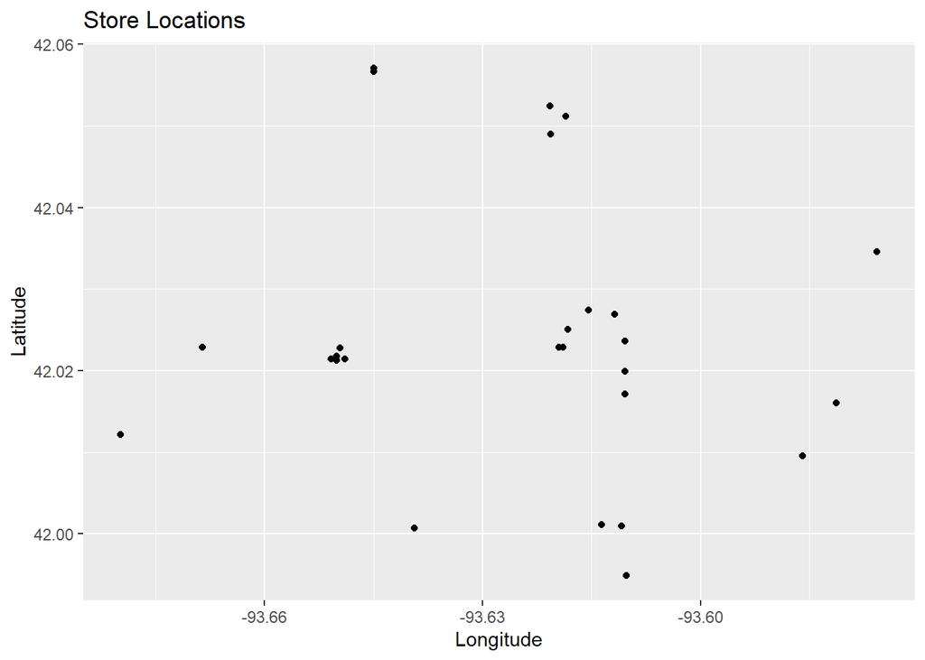

```r
AmesNoNull <- AmesClean %>%
  filter(!is.na(long)) ##removes null store locations

ggplot(AmesNoNull, aes(x = long, y=lat)) +
  geom_point() +
  xlab("Longitude") +
  ylab("Latitude") +
  labs(title = "Store Locations")
```

**Question 3b**

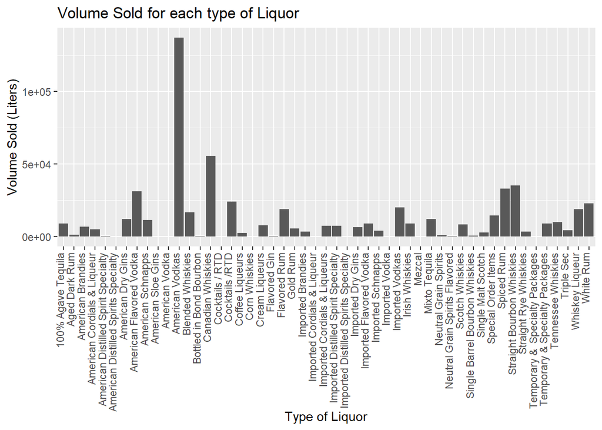

```r
ggplot(AmesClean %>% filter(`Category Name` != ""), aes(`Category Name`, `Volume Sold (Liters)`)) +
  geom_col() +
  theme(axis.text.x = element_text(angle = 90, hjust = 1, vjust = .02)) +
  xlab("Type of Liquor") +
  labs(title = "Volume Sold for each type of Liquor")
```

**Question 4**

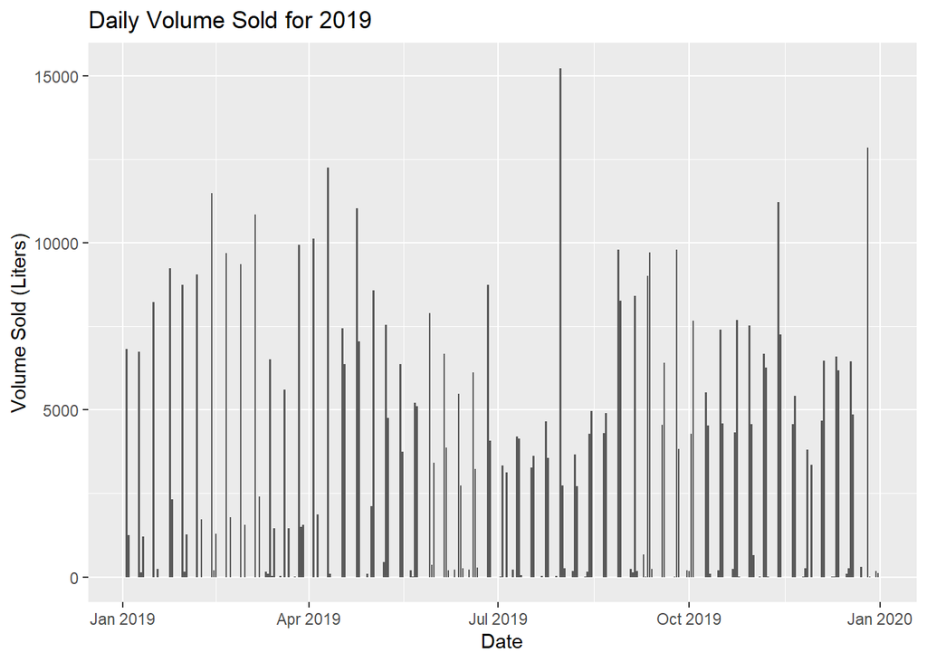

```r
#Visual Summary for the yearly trends at a glance
q4 <- AmesClean %>%
  mutate(oldDate = as.Date(mdy(oldDate))) %>%
  group_by(oldDate) %>%
  summarise(volumeSold = sum(`Volume Sold (Liters)`),
    numSales = sum(`Bottles Sold`),
    moneyMade = sum(`Sale (Dollars)`))

ggplot(q4,aes(oldDate, volumeSold)) +
  geom_col() +  #using geom_col at the request of the TA it seems to work much better than line
  scale_x_date() +
  xlab("Date") +
  ylab("Volume Sold (Liters)") +
  labs(title = "Daily Volume Sold for 2019")
```

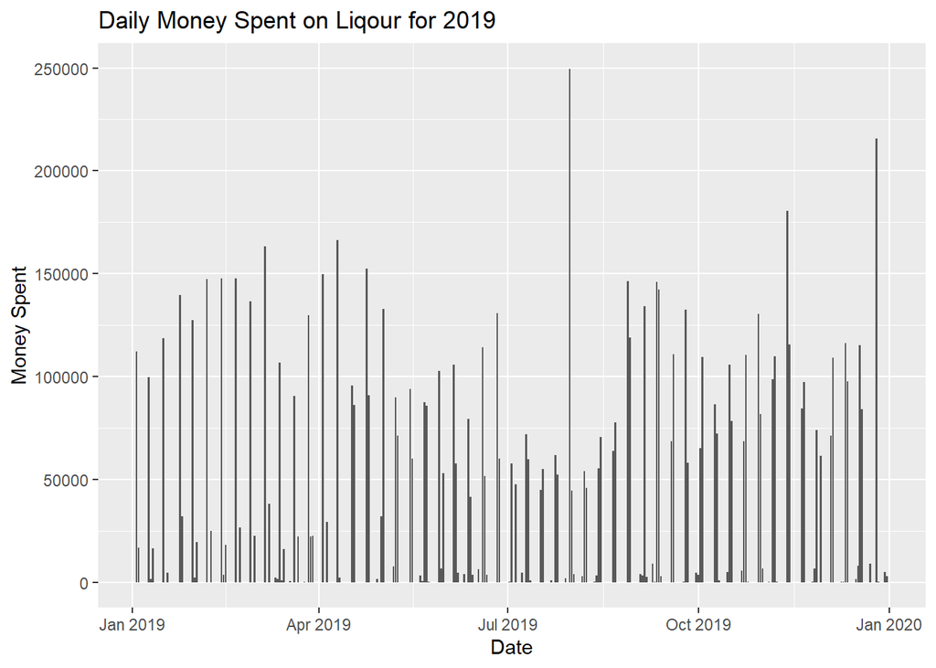

```r
ggplot(q4,aes(oldDate, moneyMade)) +
  geom_col() +
  scale_x_date() +
  xlab("Date") +
  ylab("Money Spent") +
  labs(title = "Daily Money Spent on Liqour for 2019")
```

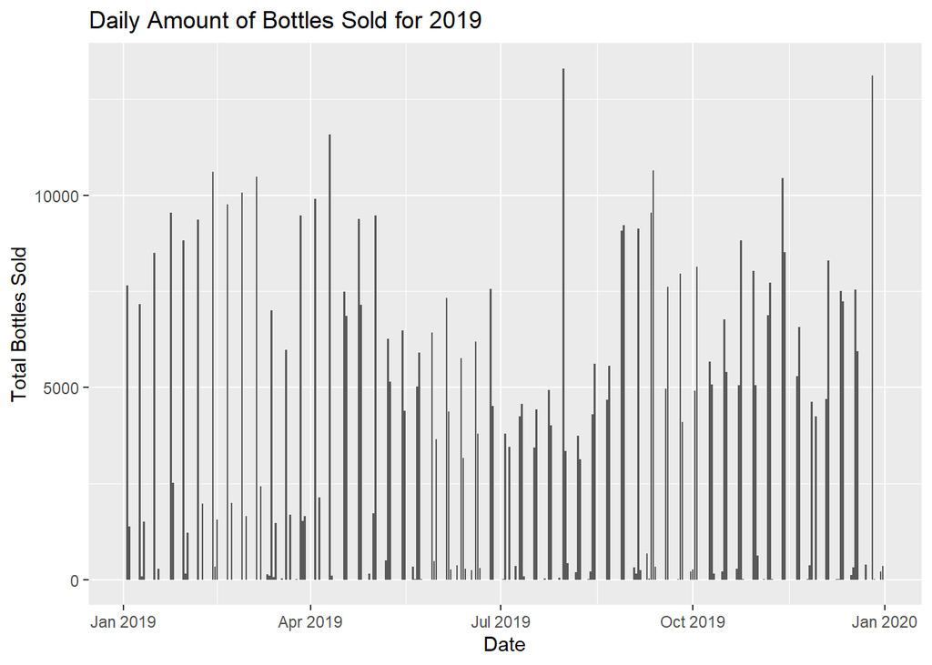

```r
ggplot(q4,aes(oldDate, numSales)) +
  geom_col() +
  scale_x_date() +
  xlab("Date") +
  ylab("Total Bottles Sold") +
  labs(title = "Daily Amount of Bottles Sold for 2019")
```

```r
#Non visual summary
nonVisualq4 <- AmesClean %>%
  group_by(Day,Month,Year) %>%
  summarise(volumeSold = sum(`Volume Sold (Liters)`),
    numSales = sum(`Bottles Sold`),
    moneyMade = sum(`Sale (Dollars)`)) %>%
  arrange(Month,Day,Year)

head(nonVisualq4)
```

```
## # A tibble: 6 x 6
## # Groups:   Day, Month [6]
##     Day Month  Year volumeSold numSales moneyMade
##   <dbl> <dbl> <dbl>      <dbl>    <dbl>     <dbl>
## 1     3     1  2019      6816.     7648   112009.
## 2     4     1  2019      1256.     1374    16766.
## 3     9     1  2019      6732.     7167    99703.
## 4    10     1  2019       135        84     1457.
## 5    11     1  2019      1205.     1499    16481.
## 6    16     1  2019      8227.     8505   118597.
```

I want to note that I chose to interpert a sale as a bottle sold. I chose this because it appears that many times hyvee reported 12 out of 12 bottles of vodka sold at once this feels like the worker was just grouping the weeks sales as I don’t know anyone who would reguraly purchase every bottle of a certain vodka in a pack. one could have chosen to use the number of rows per day as the number of sales but that felt like to severe of an underestimate for me.

**Question 5**

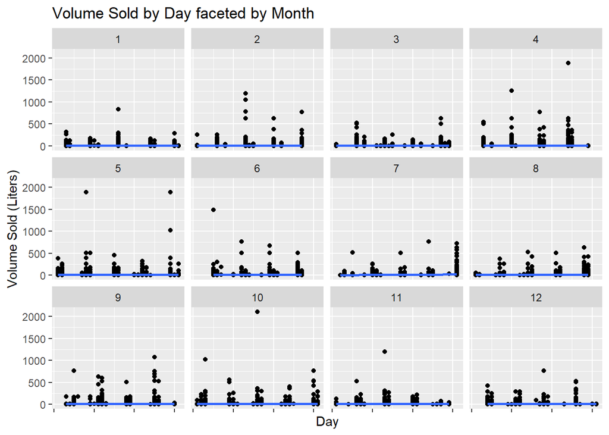

```r
ggplot(AmesClean, aes(x=Day,y=`Volume Sold (Liters)`)) +
  geom_point() +
  facet_wrap(vars(Month)) +
  geom_smooth(method = "lm") +
  theme(axis.text.x = element_blank()) +
  labs(title = "Volume Sold by Day faceted by Month")
```

Since using Geom_smooth did not appear to work to help discover trends. I will only discuss trends I see myself. First is that the sale reports all occur 4-5 times a month suggesting stores only report once a week. The second more important trend we can see is an uptike in sales during the school year looking at the end of july when students (espically those in the greeks ) start moving back to ames we see a massive amount of sales occuring. and then we see more sales occuring (not high volume sales but more sales overall).

**Question 6**

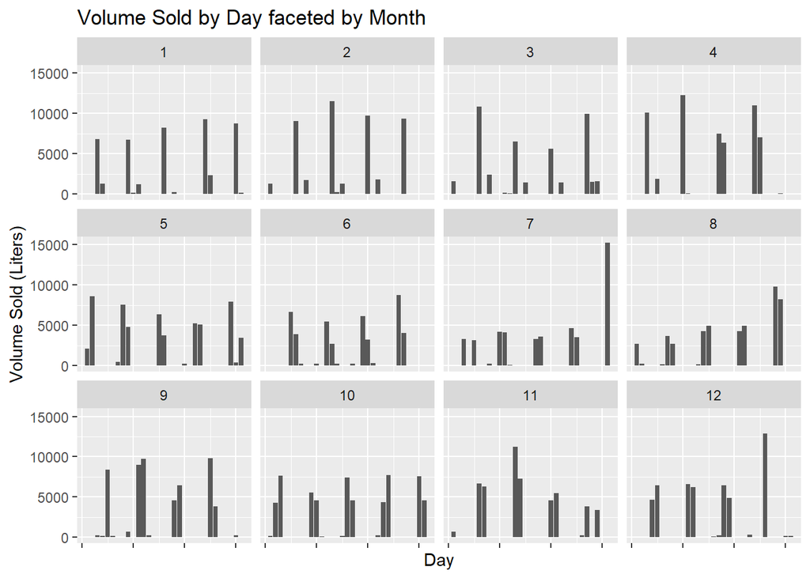

```r
homeGames <- c("8/31/2019","9/14/2019","9/21/2019","10/5/2019","10/26/2019","11/16/2019","11/23/2019")
ggplot(AmesClean, aes(x=Day,y=`Volume Sold (Liters)`)) +
  geom_col() +
  facet_wrap(vars(Month)) +
  theme(axis.text.x = element_blank()) +
  labs(title = "Volume Sold by Day faceted by Month")
```

The actual dates are not in our dataset (check using filter()) but we can look at the months and see trends on the weeks that have a home game that week is usually a peak or unusally high sale week. This does not include october however, probably due to “Halloweekend” parties that occur for the last week of the month hiding the peak from the 10/26 football game.